# Waste Collection Analysis at Degraves Street

**Authored by:** Aishwarya Mahajan  
**Level:** Intermediate  
**Pre-requisite Skills:** Python, Data Analysis, Data Visualization

## Scenario

Imagine a city striving for sustainability without efficient waste management! Effective waste collection and management are essential for maintaining a healthy environment, reducing pollution, and promoting well-being among residents. This analysis focuses on determining the factors influencing the amount of waste collected at Degraves Street recycling facility, which can guide policy-making and operational strategies for better waste management in Melbourne.

## User Story

As a responsible citizen, I am eager to explore the factors affecting waste collection at Degraves Street. By thoroughly analyzing these factors, we can identify key variables such as the time of year and city events. This investigation aligns closely with our mission to prioritize environmental sustainability and improve the well-being of Melbourne’s residents. Through this analysis, I aim to discover:

- The influence of different times of the year on waste collection.
- The impact of city events on the volume of waste collected.

## What This Use Case Will Teach

At the end of this use case, one can:

- Identify key variables contributing to the increase or decrease in the amount of waste collected.
- Analyze seasonal trends in waste collection.
- Assess the impact of city events on the volume of waste.
- Use Python for data retrieval and analysis.
- Create visualizations to present insights effectively.

## Introduction

Effective waste management is crucial for maintaining a sustainable and healthy environment. Degraves Street in Melbourne is a focal point for waste collection and recycling efforts. By analyzing the data related to waste collection, we can uncover the factors that influence waste volumes and develop strategies to optimize waste management processes. This analysis will use two primary datasets: organic waste collected at Degraves Street and event permits in the city. These datasets will help us understand how different times of the year and city events impact waste collection.

## Datasets

To complete our waste collection analysis, the following datasets will be used:

### Waste Collection Data

- **organic-waste-collected-at-degraves-st-recycling-facility-2016.csv:** Data on organic waste collected at Degraves Street recycling facility in 2016.

link: https://data.melbourne.vic.gov.au/explore/dataset/organic-waste-collected-at-degraves-st-recycling-facility-2016/information/?sort=date

### Event Data

- **event_permits_2014-2018.csv:** Information about events happening in the city, including dates and expected attendance.

link: https://data.melbourne.vic.gov.au/explore/dataset/event-permits-2014-2018-including-film-shoots-photo-shoots-weddings-christmas-pa/information/

## Expected Outcomes

- Identification of key factors influencing waste collection at Degraves Street.
- Insights into how different times of the year and city events affect waste volumes.
- Recommendations for city planners and waste management authorities to reduce waste and improve recycling rates.

## Conclusion

By understanding the factors that affect waste collection at Degraves Street, this project aims to contribute to environmental sustainability and the well-being of the city's residents. The insights gained from this analysis will support the development of effective waste management policies and practices.

## Importing Necessary Libraries

```python
# Importing standard libraries
import pandas as pd
import numpy as np
import matplotlib.pyplot as plt
import seaborn as sns

# Importing libraries for machine learning
from sklearn.model_selection import train_test_split
from sklearn.linear_model import LinearRegression
from sklearn.metrics import mean_squared_error, r2_score
from sklearn.preprocessing import LabelEncoder

# Importing libraries for data visualization
import matplotlib.pyplot as plt
import seaborn as sns

# Importing libraries for web requests and data handling
import requests
from io import StringIO

# Additional libraries will be added as needed
```

## Data Retrieval and using them as Dataframes

### Using base_url to retrieve the datasets by specified dataset ids and using them as dataframes for further analysis.

```python
# Function to collect data
def collect_data(dataset_id):
    base_url = 'https://data.melbourne.vic.gov.au/api/explore/v2.1/catalog/datasets/'
    format = 'csv'
    url = f'{base_url}{dataset_id}/exports/{format}'
    params = {
        'select': '*',
        'limit': -1,  # all records
        'lang': 'en',
        'timezone': 'UTC',
    }

    # GET request
    response = requests.get(url, params=params)

    if response.status_code == 200:
        # StringIO to read the CSV data
        url_content = response.content.decode('utf-8')
        # Try to determine the delimiter by reading the first few lines
        delimiter = ','
        sample_lines = url_content.split('\n')[:5]
        for line in sample_lines:
            if ';' in line:
                delimiter = ';'
                break
        df = pd.read_csv(StringIO(url_content), delimiter=delimiter)
        print(f'Successfully retrieved dataset: {dataset_id}')
        return df
    else:
        print(f'Request failed with status code {response.status_code}')
        return None

# Dataset IDs
dataset_ids = {
    'organic_waste': 'organic-waste-collected-at-degraves-st-recycling-facility-2016',
    'event_permits': 'event-permits-2014-2018-including-film-shoots-photo-shoots-weddings-christmas-pa'
}

# Collecting and printing data for each dataset
datasets = {}
for name, dataset_id in dataset_ids.items():
    print(f"\nCollecting data for {name}...")
    df = collect_data(dataset_id)
    if df is not None:
        datasets[name] = df
        print(f"The {name} dataset contains {len(df)} records.")
        print(df.head(3))
    else:
        print(f"Failed to retrieve the {name} dataset.")

# Assigning the datasets to variables
Waste_df = datasets.get('organic_waste')
Events_df = datasets.get('event_permits')
```

```
Successfully retrieved dataset: organic-waste-collected-at-degraves-st-recycling-facility-2016
The organic_waste dataset contains 366 records.
        day        date  gross_weight_bin_1_kg  gross_weight_bin_2_kg  \
0  Saturday  2016-01-02                   44.7                    NaN
1    Friday  2016-01-08                   65.1                   68.2
2    Sunday  2016-01-10                   81.3                    NaN

   gross_weight_bin_3_kg  gross_weight_bin_4_kg  daily_estimated_net_weight_kg
0                    NaN                    NaN                           35.7
1                    NaN                    NaN                          115.3
2                    NaN                    NaN                           72.3

Successfully retrieved dataset: event-permits-2014-2018-including-film-shoots-photo-shoots-weddings-christmas-pa
The event_permits dataset contains 2827 records.
                title event_start   event_end       category_1 category_2  \
0             Anthony  2015-02-17  2015-02-17  Filming - Movie        NaN
1  Spirit Of The Game  2015-08-18  2015-08-18  Filming - Movie        NaN
2       Ali's Wedding  2015-11-30  2015-11-30  Filming - Movie        NaN

                 location
0  Inner Suburb Locations
1         Carlton Gardens
2  Inner Suburb Locations
```

## Initial EDA on the Datasets

### Initial data analysis and preprocessing to understand the data.

```python
num_rows, num_cols = Waste_df.shape

print("Rows in the waste_df :", num_rows)
print("Columns in the waste_df is:", num_cols)

print(Waste_df.head())
```

```
Rows in the waste_df : 366
Columns in the waste_df is: 7
         day        date  gross_weight_bin_1_kg  gross_weight_bin_2_kg  \
0   Saturday  2016-01-02                   44.7                    NaN
1     Friday  2016-01-08                   65.1                   68.2
2     Sunday  2016-01-10                   81.3                    NaN
3  Wednesday  2016-01-13                   49.9                   56.9
4  Wednesday  2016-01-20                   84.0                   55.8

   gross_weight_bin_3_kg  gross_weight_bin_4_kg  daily_estimated_net_weight_kg
0                    NaN                    NaN                           35.7
1                    NaN                    NaN                          115.3
2                    NaN                    NaN                           72.3
3                   35.0                    NaN                          114.8
4                    NaN                    NaN                          121.8
```

```python
num_rows, num_cols = Events_df.shape

print("Rows in the events_df :", num_rows)
print("Columns in the events_df is:", num_cols)

print(Events_df.head())
```

```
Rows in the events_df : 2827
Columns in the events_df is: 6
                title event_start   event_end       category_1 category_2  \
0             Anthony  2015-02-17  2015-02-17  Filming - Movie        NaN
1  Spirit Of The Game  2015-08-18  2015-08-18  Filming - Movie        NaN
2       Ali's Wedding  2015-11-30  2015-11-30  Filming - Movie        NaN
3            Dogfight  2016-08-23  2016-08-23  Filming - Movie        NaN
4  Dogfight Unit Base  2016-09-21  2016-09-21  Filming - Movie        NaN

                 location
0  Inner Suburb Locations
1         Carlton Gardens
2  Inner Suburb Locations
3  Inner Suburb Locations
4       Flagstaff Gardens
```

## Data Cleaning and preprocessing

### Dropping the uncessary columns, checking for missing values and replacing them with appropriate values using reliable methods.

```python
# Print column names to identify the correct ones to drop
print("Columns in Waste_df:", Waste_df.columns)
print("Columns in Events_df:", Events_df.columns)
```

```
Columns in Waste_df: Index(['day', 'date', 'gross_weight_bin_1_kg', 'gross_weight_bin_2_kg',
       'gross_weight_bin_3_kg', 'gross_weight_bin_4_kg',
       'daily_estimated_net_weight_kg'],
      dtype='object')
Columns in Events_df: Index(['title', 'event_start', 'event_end', 'category_1', 'category_2',
       'location'],
      dtype='object')
```

```python
# Dropping unnecessary columns from Waste_df
columns_to_drop_waste = ['gross_weight_bin_1_kg', 'gross_weight_bin_2_kg', 'gross_weight_bin_3_kg', 'gross_weight_bin_4_kg']
Waste_df.drop(columns=columns_to_drop_waste, inplace=True)

# Dropping unnecessary columns from Events_df
columns_to_drop_events = ['title', 'category_2']
Events_df.drop(columns=columns_to_drop_events, inplace=True)

# Checking the results
print("\nAfter dropping unnecessary columns:")
print("\nWaste_df:")
print(Waste_df.head())
print("\nEvents_df:")
print(Events_df.head())
```

```
After dropping unnecessary columns:

Waste_df:
         day        date  daily_estimated_net_weight_kg
0   Saturday  2016-01-02                           35.7
1     Friday  2016-01-08                          115.3
2     Sunday  2016-01-10                           72.3
3  Wednesday  2016-01-13                          114.8
4  Wednesday  2016-01-20                          121.8

Events_df:
  event_start   event_end       category_1                location
0  2015-02-17  2015-02-17  Filming - Movie  Inner Suburb Locations
1  2015-08-18  2015-08-18  Filming - Movie         Carlton Gardens
2  2015-11-30  2015-11-30  Filming - Movie  Inner Suburb Locations
3  2016-08-23  2016-08-23  Filming - Movie  Inner Suburb Locations
4  2016-09-21  2016-09-21  Filming - Movie       Flagstaff Gardens
```

```python
# Display the shape of the modified dataframes
num_rows_waste, num_cols_waste = Waste_df.shape
num_rows_events, num_cols_events = Events_df.shape

print(f"\nWaste_df now has {num_rows_waste} rows and {num_cols_waste} columns.")
print(f"Events_df now has {num_rows_events} rows and {num_cols_events} columns.")
```

```
Waste_df now has 366 rows and 3 columns.
Events_df now has 2827 rows and 4 columns.
```

## Checking for missing values

```python
# Check for missing values in Waste_df
missing_values_waste = Waste_df.isnull().sum()

# Check for missing values in Events_df
missing_values_events = Events_df.isnull().sum()

print("Missing values in Waste_df:")
print(missing_values_waste)
print("\nMissing values in Events_df:")
print(missing_values_events)
```

```
Missing values in Waste_df:
day                              0
date                             0
daily_estimated_net_weight_kg    7
dtype: int64

Missing values in Events_df:
event_start    0
event_end      4
category_1     0
location       5
dtype: int64
```

## Calculating the skewness of columns having missing values

### Skewness will help in determining the method to be used for imputing the missing data.

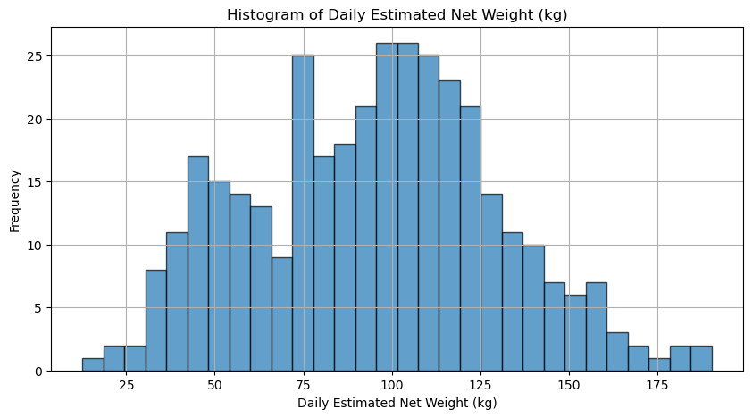

```
Skewness of 'daily_estimated_net_weight_kg': 0.08145378145663432
```

```python
# Draw histogram and calculate skewness for 'daily_estimated_net_weight_kg' in Waste_df
plt.figure(figsize=(10, 5))
plt.hist(Waste_df['daily_estimated_net_weight_kg'].dropna(), bins=30, edgecolor='k', alpha=0.7)
plt.title('Histogram of Daily Estimated Net Weight (kg)')
plt.xlabel('Daily Estimated Net Weight (kg)')
plt.ylabel('Frequency')
plt.grid(True)
plt.show()

waste_skewness = Waste_df['daily_estimated_net_weight_kg'].dropna().skew()
print(f"Skewness of 'daily_estimated_net_weight_kg': {waste_skewness}\n")
```

### Given that the skewness of daily_estimated_net_weight_kg is very close to 0 (0.081), indicating that the distribution is approximately symmetric, it is appropriate to fill the missing values with the mean.

### Imputing missing values with Mean

```python
# Calculate the mean of 'daily_estimated_net_weight_kg'
mean_weight = Waste_df['daily_estimated_net_weight_kg'].mean()

# Fill missing values with the mean
Waste_df['daily_estimated_net_weight_kg'].fillna(mean_weight, inplace=True)

# Verify that there are no missing values left
print(Waste_df.isnull().sum())
```

```
day                              0
date                             0
daily_estimated_net_weight_kg    0
dtype: int64
```

```python
# Drop rows with missing 'event_end' values
Events_df_cleaned = Events_df.dropna(subset=['event_end'])

# Fill missing values in 'location' with 'Unknown'
Events_df_cleaned['location'].fillna('Unknown', inplace=True)

# Verify that there are no missing values left
print("Missing values in Events_df_cleaned after handling:")
print(Events_df_cleaned.isnull().sum())
```

```
Missing values in Events_df_cleaned after handling:
event_start    0
event_end      0
category_1     0
location       0
dtype: int64
```

## Encoding categorical variable

### Encoding the categorical variable to numeric values using label encoding

```python
# Create a label encoder
label_encoder = LabelEncoder()

# Fit and transform the 'category_1' column
Events_df_cleaned['category_1_encoded'] = label_encoder.fit_transform(Events_df_cleaned['category_1'])

# Drop the original 'category_1' column
Events_df_cleaned.drop(columns=['category_1'], inplace=True)

# Display the unique values and their corresponding encoded values
category_mapping = dict(zip(label_encoder.classes_, label_encoder.transform(label_encoder.classes_)))
print("Category to Numeric Mapping:\n", category_mapping)

# Display the first few rows to check the encoded column
print(Events_df_cleaned.head())
```

[output not shown]

## Performing Descriptive and Time Series Analysis

### Descriptive Statistics

Calculating summary statistics to understand the distribution of numerical columns.

### Time Series Analysis

```python
# Descriptive statistics for Waste_df
print("Descriptive statistics for Waste_df:")
print(Waste_df.describe())

# Descriptive statistics for Events_df_cleaned
print("\nDescriptive statistics for Events_df_cleaned:")
print(Events_df_cleaned.describe())
```

```
Descriptive statistics for Waste_df:
       daily_estimated_net_weight_kg
count                     366.000000
mean                       95.014485
std                        34.399736
min                        12.600000
25%                        71.850000
50%                        96.300000
75%                       117.875000
max                       190.400000

Descriptive statistics for Events_df_cleaned:
       category_1_encoded
count         2823.000000
mean            19.679065
std             10.895341
min              0.000000
25%             10.000000
50%             25.000000
75%             31.000000
max             32.000000
```

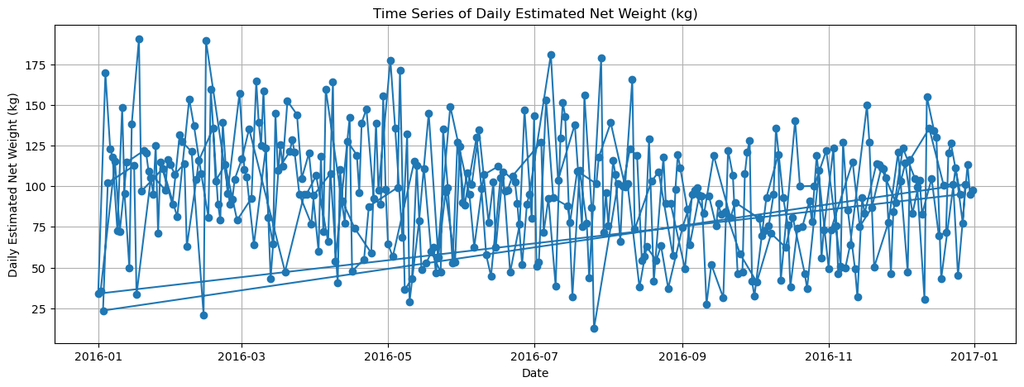

```python
# Convert 'date' to datetime format in Waste_df
Waste_df['date'] = pd.to_datetime(Waste_df['date'])

# Plot time series of daily estimated net weight
plt.figure(figsize=(15, 5))
plt.plot(Waste_df['date'], Waste_df['daily_estimated_net_weight_kg'], marker='o')
plt.title('Time Series of Daily Estimated Net Weight (kg)')
plt.xlabel('Date')
plt.ylabel('Daily Estimated Net Weight (kg)')
plt.grid(True)
plt.show()
```

## Implementing Feature Engineering

```
Columns with NaN values:
day                              0
date                             0
daily_estimated_net_weight_kg    0
day_of_week                      0
month                            0
season                           0
is_weekend                       0
rolling_avg_7d                   0
dtype: int64

First few rows of the engineered dataset:
         day       date  daily_estimated_net_weight_kg  day_of_week  month  \
0   Saturday 2016-01-02                           35.7            5      1
1     Friday 2016-01-08                          115.3            4      1
2     Sunday 2016-01-10                           72.3            6      1
3  Wednesday 2016-01-13                          114.8            2      1
4  Wednesday 2016-01-20                          121.8            2      1

   season  is_weekend  rolling_avg_7d
0  Summer           1       95.014485
1  Summer           0       95.014485
2  Summer           1       95.014485
3  Summer           0       95.014485
4  Summer           0       95.014485
```

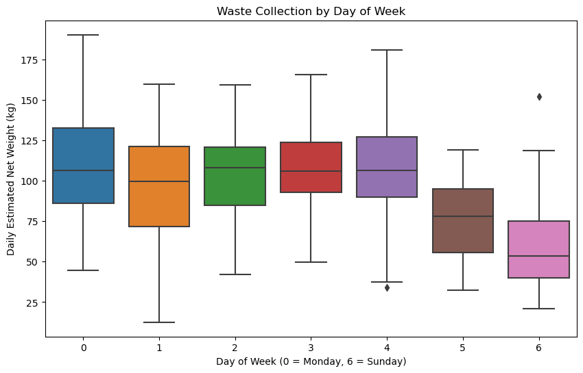

```python
def engineer_features(df):
    # Add day of week
    df['day_of_week'] = df['date'].dt.dayofweek

    # Add month
    df['month'] = df['date'].dt.month

    # Add season
    df['season'] = df['date'].dt.month.map({1: 'Summer', 2: 'Summer', 3: 'Autumn',
                                            4: 'Autumn', 5: 'Autumn', 6: 'Winter',
                                            7: 'Winter', 8: 'Winter', 9: 'Spring',
                                            10: 'Spring', 11: 'Spring', 12: 'Summer'})

    # Add is_weekend flag
    df['is_weekend'] = df['day_of_week'].isin([5, 6]).astype(int)

    # Add rolling average (7-day window)
    df['rolling_avg_7d'] = df['daily_estimated_net_weight_kg'].rolling(window=7).mean()

    # Fill NaN values in rolling_avg_7d with the overall mean
    overall_mean = df['daily_estimated_net_weight_kg'].mean()
    df['rolling_avg_7d'].fillna(overall_mean, inplace=True)

    return df

# Use the function
Waste_df_engineered = engineer_features(Waste_df)

# Check for any remaining NaN values
print("Columns with NaN values:")
print(Waste_df_engineered.isnull().sum())

# Display the first few rows
print("\nFirst few rows of the engineered dataset:")
print(Waste_df_engineered.head())

# Visualize waste by day of week
plt.figure(figsize=(10, 6))
sns.boxplot(x='day_of_week', y='daily_estimated_net_weight_kg', data=Waste_df_engineered)
plt.title('Waste Collection by Day of Week')
plt.xlabel('Day of Week (0 = Monday, 6 = Sunday)')
plt.ylabel('Daily Estimated Net Weight (kg)')
plt.show()
```

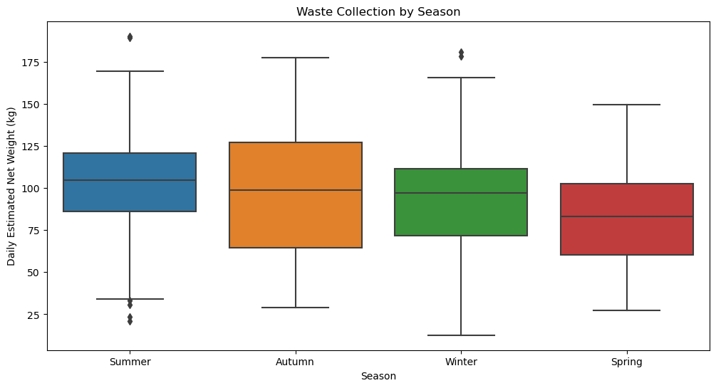

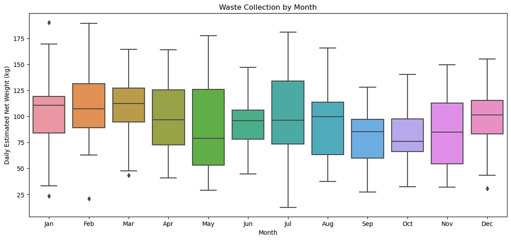

```
Average waste collection by season:
season
Summer    102.914604
Autumn     99.942706
Winter     94.457924
Spring     82.694665
Name: daily_estimated_net_weight_kg, dtype: float64

Average waste collection by month:
month
3     110.094483
2     109.665517
1     101.529500
7     100.103226
4      99.816667
12     97.984338
6      92.230966
8      90.967742
5      89.912903
11     86.046667
9      81.443333
10     80.661758
Name: daily_estimated_net_weight_kg, dtype: float64
```

```python
def plot_waste_by_season(df):
    plt.figure(figsize=(12, 6))
    sns.boxplot(x='season', y='daily_estimated_net_weight_kg', data=df, order=['Summer', 'Autumn', 'Winter', 'Spring'])
    plt.title('Waste Collection by Season')
    plt.xlabel('Season')
    plt.ylabel('Daily Estimated Net Weight (kg)')
    plt.show()

def plot_waste_by_month(df):
    plt.figure(figsize=(14, 6))
    sns.boxplot(x='month', y='daily_estimated_net_weight_kg', data=df)
    plt.title('Waste Collection by Month')
    plt.xlabel('Month')
    plt.ylabel('Daily Estimated Net Weight (kg)')
    plt.xticks(range(12), ['Jan', 'Feb', 'Mar', 'Apr', 'May', 'Jun', 'Jul', 'Aug', 'Sep', 'Oct', 'Nov', 'Dec'])
    plt.show()

# Use the functions
plot_waste_by_season(Waste_df_engineered)
plot_waste_by_month(Waste_df_engineered)

# Calculate average waste collection by season
seasonal_avg = Waste_df_engineered.groupby('season')['daily_estimated_net_weight_kg'].mean().sort_values(ascending=False)
print("Average waste collection by season:")
print(seasonal_avg)

# Calculate average waste collection by month
monthly_avg = Waste_df_engineered.groupby('month')['daily_estimated_net_weight_kg'].mean().sort_values(ascending=False)
print("\nAverage waste collection by month:")
print(monthly_avg)
```

## Seasonal and Monthly Waste Collection Analysis

### Interpretation:

- Higher waste collection in Summer and Autumn could be due to increased outdoor activities, tourism, or seasonal events.

### Average Waste Collection by Month (Top 5):

- **March**: 110.09 kg
- **February**: 109.67 kg
- **January**: 101.53 kg
- **July**: 100.10 kg
- **April**: 99.82 kg

### Interpretation:

- The peak in February-March may be linked to specific events or activities in the city.
- The dip in September-October could be due to fewer events or reduced tourism.
- Monthly variability suggests other factors, such as events or weather patterns, influence waste collection.

### Key Insights:

- Clear seasonal pattern: higher waste collection in summer months.
- February-March transition sees the highest waste collection, which could inform resource allocation.
- Variability indicates the need for an adaptive waste management strategy, with increased capacity during summer and early autumn, and potentially reduced services during spring.

```python
## Evaluating and visualising correlation between events and waste collection data
```

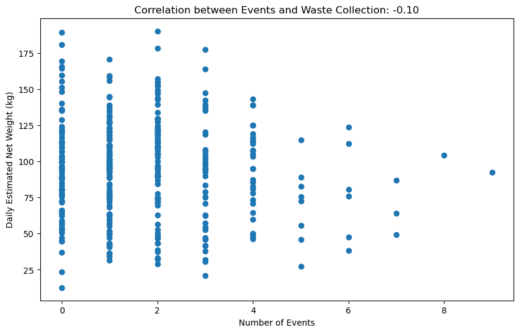

```
Correlation between events and waste collection: -0.09582366009400153

Average waste collection on event days: 94.62343144320859
Average waste collection on non-event days: 96.4125

t-statistic: -0.41073737422903217
p-value: 0.6815067994767654
```

```python
def analyze_event_correlation(waste_df, events_df):
    # Convert event_start to datetime
    events_df['event_start'] = pd.to_datetime(events_df['event_start'])

    # Count events per day
    event_counts = events_df.groupby(events_df['event_start'].dt.date).size().reset_index(name='event_count')
    event_counts['event_start'] = pd.to_datetime(event_counts['event_start'])

    # Merge waste data with event counts
    merged_df = pd.merge(waste_df, event_counts, left_on='date', right_on='event_start', how='left')
    merged_df['event_count'].fillna(0, inplace=True)

    # Calculate correlation
    correlation = merged_df['daily_estimated_net_weight_kg'].corr(merged_df['event_count'])

    # Visualize relationship
    plt.figure(figsize=(10, 6))
    plt.scatter(merged_df['event_count'], merged_df['daily_estimated_net_weight_kg'])
    plt.title(f'Correlation between Events and Waste Collection: {correlation:.2f}')
    plt.xlabel('Number of Events')
    plt.ylabel('Daily Estimated Net Weight (kg)')
    plt.show()

    return correlation, merged_df

# Use the function
correlation, merged_data = analyze_event_correlation(Waste_df_engineered, Events_df_cleaned)
print(f"Correlation between events and waste collection: {correlation}")

# Analyze waste collection on event days vs non-event days
event_day_waste = merged_data[merged_data['event_count'] > 0]['daily_estimated_net_weight_kg']
non_event_day_waste = merged_data[merged_data['event_count'] == 0]['daily_estimated_net_weight_kg']

print("\nAverage waste collection on event days:", event_day_waste.mean())
print("Average waste collection on non-event days:", non_event_day_waste.mean())

# Perform t-test to check if the difference is statistically significant
from scipy import stats
t_stat, p_value = stats.ttest_ind(event_day_waste, non_event_day_waste)
print(f"\nt-statistic: {t_stat}")
print(f"p-value: {p_value}")
```

# Conclusion

## Key Insights and Takeaways

As a data science student analyzing waste collection at Degraves Street, several critical insights were uncovered that highlight the relationships between time, events, and waste volumes:

### 2. Monthly Trends

Waste collection varies significantly by month, with **March** having the highest average waste collection at 110.09 kg. This could be associated with specific events or a general increase in activity in the city during this time. Similarly, **February** and **January** also reflect high waste volumes. However, **September** and **October** show the lowest averages, aligning with reduced events and tourism in these months.

### 3. Impact of Events

Events do not seem to have a strong correlation with waste collection, as evidenced by the correlation value of -0.0958. This suggests that while there may be a relationship between events and waste volume, it is not statistically significant. The average waste collected on event days (94.62 kg) is only slightly lower than on non-event days (96.41 kg), indicating minimal impact.

### 4. Descriptive Analysis

Waste collection values range from a minimum of 12.6 kg to a maximum of 190.4 kg, with a mean value of 95.01 kg. This broad range suggests a high variability in daily waste collection, possibly influenced by a combination of factors such as weather conditions, public holidays, or random fluctuations in city activities.

### 6. Correlation and T-tests

A t-test comparing waste volumes on event and non-event days further supports the observation of little to no difference between the two groups. The p-value of 0.68 indicates no statistically significant difference, meaning events might not drastically change waste collection patterns.

## Strategic Implications for Waste Management

- **Seasonal Resource Allocation**: Given that waste volumes are higher in summer and autumn, city planners could allocate more resources to waste collection during these periods, while reducing capacity in spring and winter when volumes are lower.
- **Event-Based Adjustments**: Despite events having a minimal statistical impact, there could still be targeted strategies during major city events, ensuring adequate waste management services are available when necessary.
- **Long-Term Trends**: The monthly and seasonal patterns uncovered in this analysis provide valuable insights into long-term waste management planning. By preparing for peak months (February-March) and adapting services during low-collection periods (September-October), the city can optimize its waste collection efforts.

## Final Thoughts

The waste collection analysis at Degraves Street provides a comprehensive understanding of how various factors, such as seasons, events, and daily trends, affect waste volumes. By leveraging data science techniques like feature engineering, time series analysis, and statistical testing, this analysis offers actionable insights for policymakers and waste management teams. These findings contribute toward Melbourne’s sustainability efforts by ensuring more efficient and data-driven waste collection strategies.